# HW: Matching and Weighting

Samuel Snelson

2023-05-04

```r
load(here("data/exercise_data.RData"))
```

```r
d <- d |>
  mutate(treat_fac = factor(treat))

d_exper <- d_exper |>
  mutate(treat_fac = factor(treat))
```

1. Use the experimental data to estimate the effect of the job training treatment. How much does it appear to affect 1978 income? Now look at the observational data (for all exercises from now on). How large is the raw difference in 1978 income between the treatment group and the PSID comparison group?

```r
# calculating difference in re78 between treatment groups

d_exper |> # with experimental data
  group_by(treat) |>
  summarize(mean = mean(re78),
            conf.low = mean - (1.96 * (sqrt(sd(re78) / n()))),
            conf.high = mean + (1.96 * (sqrt(sd(re78) / n()))))
```

```
## # A tibble: 2 × 4
##   treat  mean conf.low conf.high
##   <int> <dbl>    <dbl>     <dbl>
## 1     0  5.09     4.86      5.32
## 2     1  5.98     5.68      6.28
```

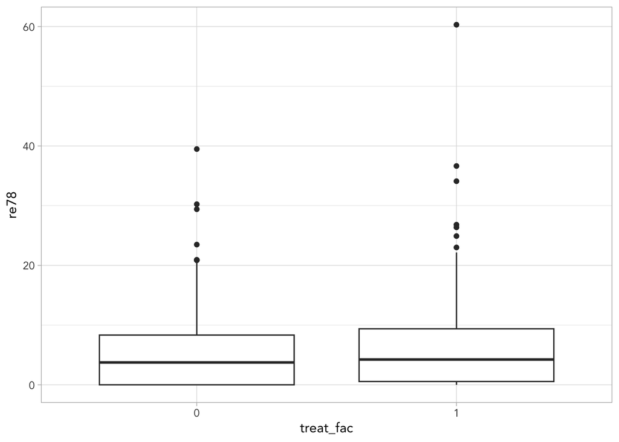

```r
# plotting boxplot of difference
ggplot(d_exper) +
  geom_boxplot(aes(treat_fac, re78))
```

```r
# With the whole dataset, the difference is much larger! Does this disguide difference other than the treatment?? Let's match/weight
d |> # with experimental data
  group_by(treat) |>
  summarize(mean = mean(re78),
            conf.low = mean - (1.96 * (sqrt(sd(re78) / n()))),
            conf.high = mean + (1.96 * (sqrt(sd(re78) / n()))))
```

```
## # A tibble: 2 × 4
##   treat  mean conf.low conf.high
##   <int> <dbl>    <dbl>     <dbl>
## 1     0 22.5     22.4      22.7
## 2     1  5.98     5.68      6.28
```

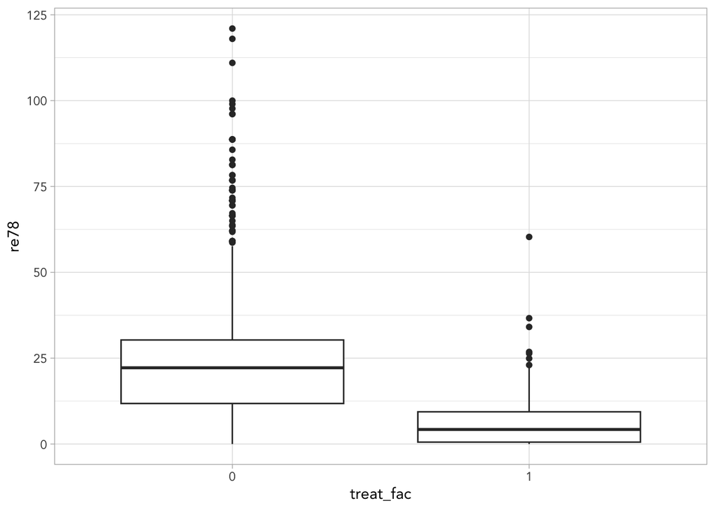

```r
ggplot(d) +
  geom_boxplot(aes(treat_fac, re78))
```

> For the experimental data, the treatment group is estimated to make about $866 more. With the whole data set, the treatment group, oddly, is estimated to make about $16,500 less.
2. Try to estimate the effect of the treatment using regression. What does regression say the effect of the program is?

```r
(m1 <- lm(re78 ~ treat,
         data = d)) # effect is about 16.5 (like the difference of 22.5 - 6.92)
```

```
##
## Call:
## lm(formula = re78 ~ treat, data = d)
##
## Coefficients:
## (Intercept)        treat
##       22.52       -16.54
```

```r
# Wow the regression gives us the same thing as the naive estimate of the raw difference before any adjustments
```

> The effect is about 16.5, the same as the difference in the raw means between the treated and control group.
3. Begin by exact matching on all the dummy variables. How many treated cases cannot be matched? What is the (FS)ATT estimate?

```r
ex_m1 <- matchit(treat ~ black + hisp + married +
                   nodegr + u74 + u75,
                 data = d,
                 method = "exact")

d_ex <- match.data(ex_m1)

ex_att <- lm(re78 ~ treat,
             data = d_ex,
             weights = weights)

tidy(ex_att,
     conf.int = TRUE)
```

```
## # A tibble: 2 × 7
##   term        estimate std.error statistic   p.value conf.low conf.high
##   <chr>          <dbl>     <dbl>     <dbl>     <dbl>    <dbl>     <dbl>
## 1 (Intercept)     8.24     0.232     35.6  1.27e-222     7.79      8.70
## 2 treat          -2.39     0.667     -3.58 3.54e-  4    -3.69     -1.08
```

> There are about 10 treated cases that were dropped and 131 cases which were unable to be matched.

> With exact matching on marital status, whether a respondent was black or hispanic, degree status, and whether they had income in 1974 and ’75, the effect of the treatment is estimated to reduce income by between about $3,600 to about $1,000.
4. Use the observational data to estimate each case’s propensity to receive treatment using glm(). Use a logistic regression with quadratic terms for age, education, 1974 income, and 1975 income. Spend a few moments thinking about what this model says. If you are familiar with plotting in R, look at the density plots of the p-score for treated and untreated groups. (If not, you can move on. We’ll do the same thing using bal.plot() in a bit.)

```r
ps <- glm(treat ~ black + hisp + nodegr + married + u74 + u75 + age + educ + re74 + re75 +
            age^2 + educ^2 + re74^2 + re75^2,
          family = binomial(link = "logit"),
          data = d)
tidy(ps,
     conf.int = TRUE)
```

[output not shown]

[output cut: 168 more lines]

[output not shown]

```
## # A tibble: 11 × 7
##    term        estimate std.error statistic  p.value conf.low conf.high
##    <chr>          <dbl>     <dbl>     <dbl>    <dbl>    <dbl>     <dbl>
##  1 (Intercept)  2.02       1.08       1.88  6.01e- 2  -0.0707    4.15
##  2 black        2.11       0.271      7.78  7.23e-15   1.59      2.65
##  3 hisp         2.42       0.443      5.46  4.78e- 8   1.55      3.29
##  4 nodegr       0.434      0.306      1.42  1.57e- 1  -0.167     1.04
##  5 married     -1.93       0.223     -8.62  6.68e-18  -2.37     -1.49
##  6 u74          2.51       0.462      5.43  5.64e- 8   1.63      3.45
##  7 u75         -1.28       0.441     -2.90  3.69e- 3  -2.17     -0.433
##  8 age         -0.114      0.0154    -7.40  1.40e-13  -0.145    -0.0847
##  9 educ        -0.00959    0.0650    -0.148 8.83e- 1  -0.137     0.118
## 10 re74        -0.0170     0.0242    -0.702 4.82e- 1  -0.0653    0.0296
## 11 re75        -0.150      0.0275    -5.44  5.33e- 8  -0.205    -0.0970
```

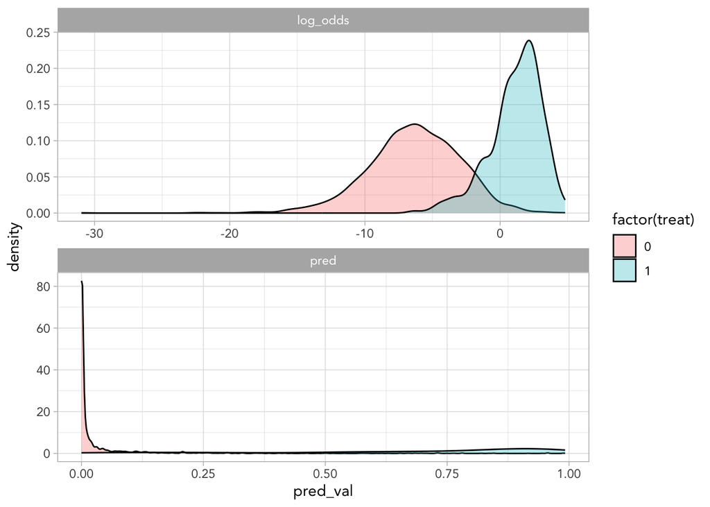

```r
d |>
  mutate(pred = predict(ps, type = "response"),
         log_odds = predict(ps, type = "link")) |>
  pivot_longer(cols = c(pred, log_odds),
               names_to = "type",
               values_to = "pred_val") |>
  ggplot(aes(pred_val,
             fill = factor(treat)),
         after_stat(scaled)) +
  geom_density(alpha = 0.3) +
  facet_wrap(~ type, nrow = 2,
             scales = "free")
```

> The propensity of being treated is very difference between the treatment and control groups. For matching/weighting, we want these to be similar! The log odds scale shows that there is some overlap but these groups have different propensities of treatment.
5. Conduct 1:1 nearest-neighbor matching on the log odds of the propensity score. Use bal.plot() to compare the overall propensity score distributions. Do once without replacement and once with replacement. Why do you think there’s a difference? Try to figure it out. Estimate the ATT for each assumption (i.e., with or without replacement). If you achieve good overall balance on the propensity score, try checking individual covariate balance using love.plot().

```r
ps_norep <- matchit(treat ~ black + hisp + nodegr + married + u74 + u75 + age + educ + re74 + re75 +
            age^2 + educ^2 + re74^2 + re75^2,
            data = d,
            estimand = "ATT",
            replace = FALSE)

ps_norep_df <- match.data(ps_norep)

lm(re78 ~ treat,
   data = ps_norep_df,
   weights = weights)
```

```
##
## Call:
## lm(formula = re78 ~ treat, data = ps_norep_df, weights = weights)
##
## Coefficients:
## (Intercept)        treat
##      10.262       -4.286
```

```r
ps_rep <- matchit(treat ~ black + hisp + nodegr + married + u74 + u75 + age + educ + re74 + re75 +
            age^2 + educ^2 + re74^2 + re75^2,
            data = d,
            estimand = "ATT",
            replace = TRUE)

ps_rep_df <- match.data(ps_rep)

lm(re78 ~ treat,
   data = ps_rep_df,
   weights = weights)
```

```
##
## Call:
## lm(formula = re78 ~ treat, data = ps_rep_df, weights = weights)
##
## Coefficients:
## (Intercept)        treat
##      6.7443      -0.7679
```

> It seems that if we allow the matching process to use the same cases multiple times (i.e., replace), then we et a better estimate of the effect of the treatment (closer to an actual gain of money adjusting for all covariates).

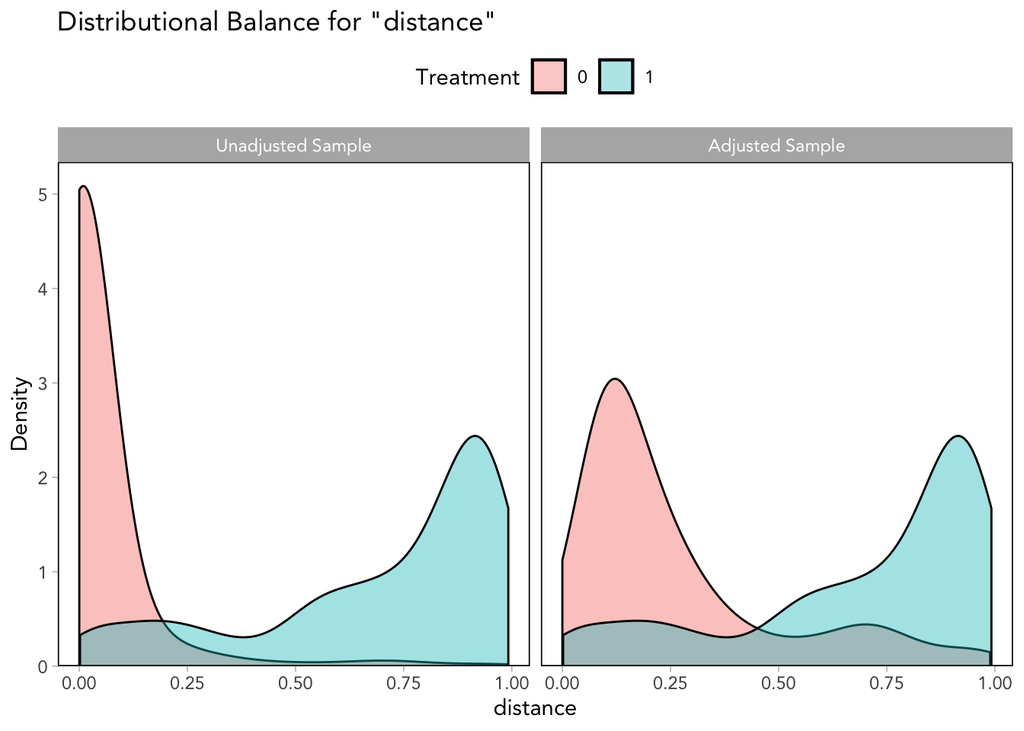

```r
bal.plot(ps_norep,
         which = "both",
         type = "density",
         var.name = "distance") +
  theme(legend.position = "top")
```

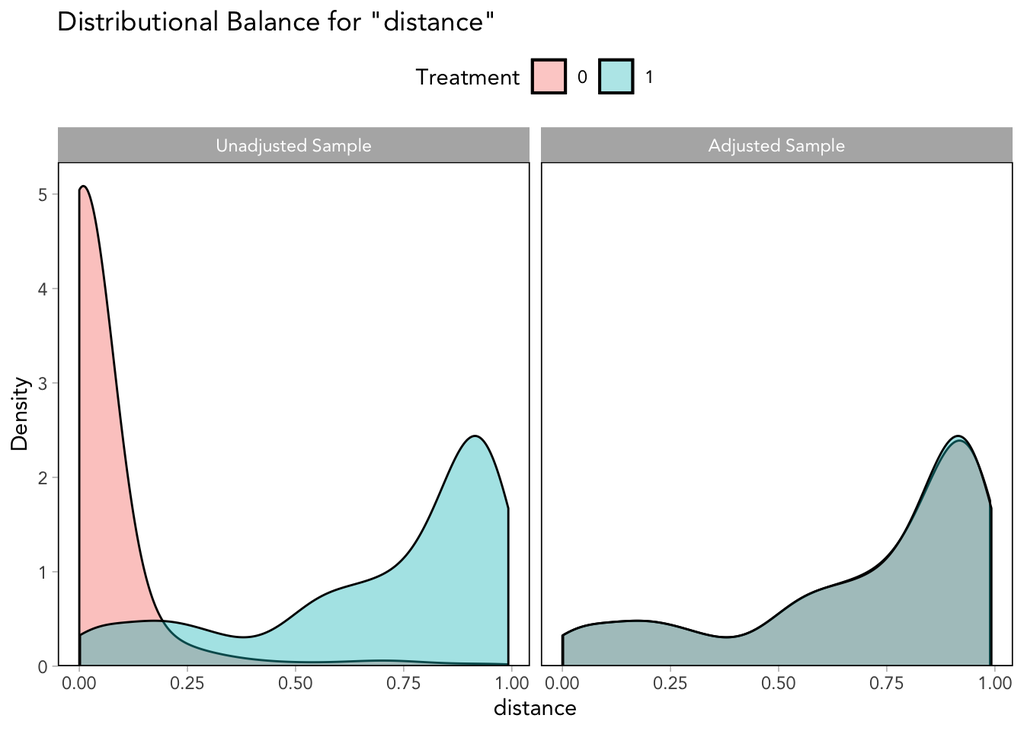

```r
bal.plot(ps_rep,
         which = "both",
         type = "density",
         var.name = "distance") +
  theme(legend.position = "top")
```

> We can see quite clearly that in the no-replace model, there is no meaningful balance in the model covariates while the replacement model gets us much closer to covariate balance.
6. Estimate propensity scores and ATT weights using weightit(). Ignore the warning you get. We’ll discuss that more in class. Estimate the ATT. Check for covariate balance.

```r
ps_weight <- weightit(treat ~ black + hisp + nodegr + married + u74 + u75 + age + educ + re74 + re75 +
            age^2 + educ^2 + re74^2 + re75^2,
            data = d,
            method = "ps",
            estimand = "ATT")
```

```
## Warning: Some extreme weights were generated. Examine them with `summary()` and
## maybe trim them with `trim()`.
```

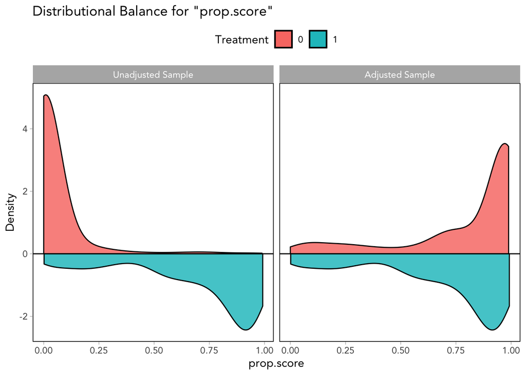

```r
bal.plot(ps_weight,
         var.name = "prop.score",
         which = "both",
         type = "density",
         mirror = TRUE) +
  theme(legend.position = "top")
```

> For propensity scores, the balance isn’t so bad but isn’t as great as it could be.

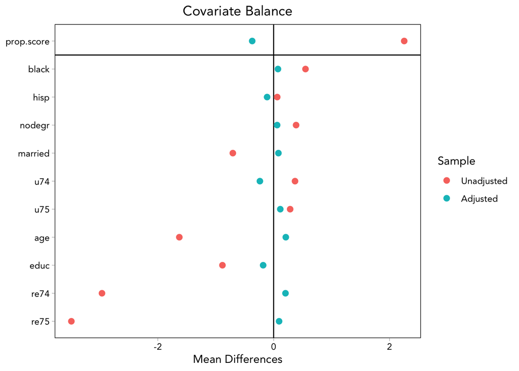

```r
love.plot(ps_weight)
```

> Looking at the mean differences in raw and weighted samples, there is a difference, but it’s not quite as balanced as we are looking for.

```r
lm(re78 ~ treat,
   data = d,
   weights = ps_weight$weights)
```

```
##
## Call:
## lm(formula = re78 ~ treat, data = d, weights = ps_weight$weights)
##
## Coefficients:
## (Intercept)        treat
##       4.842        1.134
```

> With the weighted data, the ATT estimate actually exceeds the experimental prediction of about $1,134 gained relative to a prediction of about $866.
7. Now do the same as above using covariate balancing propensity scores.

```r
cov_bal_weight <- weightit(treat ~ black + hisp + nodegr + married + u74 + u75 + age + educ + re74 + re75 +
            age^2 + educ^2 + re74^2 + re75^2,
            data = d,
            method = "cbps",
            over = TRUE,
            estimand = "ATT")
```

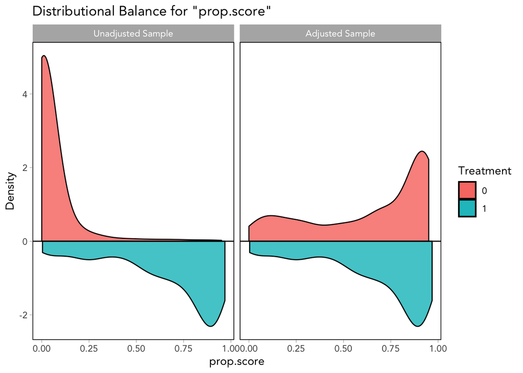

```r
bal.plot(cov_bal_weight,
         var.name = "prop.score",
         which = "both",
         type = "density",
         mirror = TRUE)
```

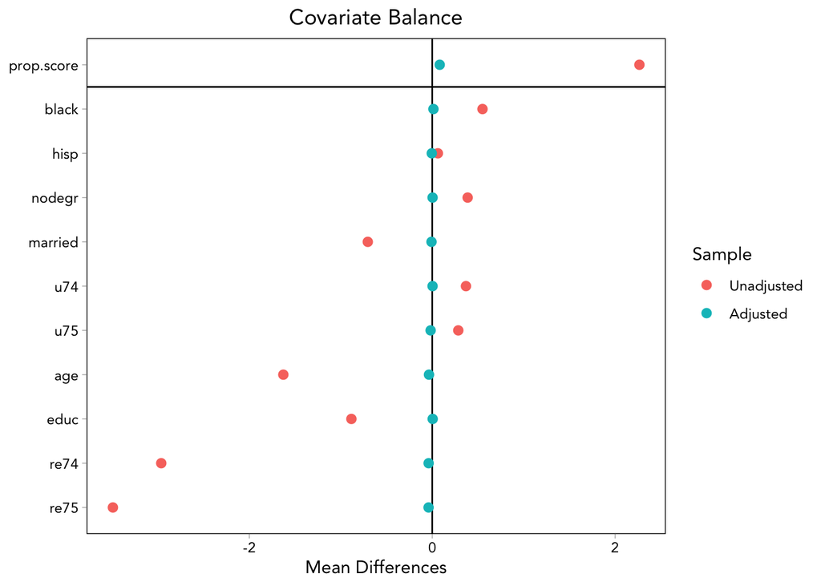

```r
love.plot(cov_bal_weight)
```

> This is an improvement in balance but not as great as we can do.

```r
lm(re78 ~ treat,
   data = d,
   weights = cov_bal_weight$weights)
```

```
##
## Call:
## lm(formula = re78 ~ treat, data = d, weights = cov_bal_weight$weights)
##
## Coefficients:
## (Intercept)        treat
##      5.7829       0.1935
```

> Here, we see that the ATT estimate is a bit of an underestimate of the experimental prediction.
8. Try Mahalanobis distance matching with replacement and using a caliper of .1. How many unique control cases get matched?

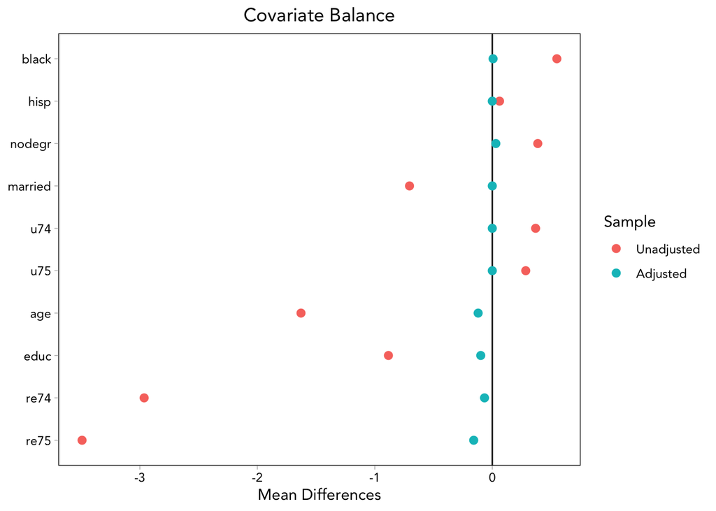

```r
mahal_match <- matchit(treat ~ black + hisp + nodegr + married + u74 + u75 + age + educ + re74 + re75 +
            age^2 + educ^2 + re74^2 + re75^2,
            data = d,
            distance = "mahalanobis",
            replace = TRUE,
            estimand = "ATT")

love.plot(mahal_match)
```

```r
lm(re78 ~ treat,
   data = d,
   weights = mahal_match$weights)
```

```
##
## Call:
## lm(formula = re78 ~ treat, data = d, weights = mahal_match$weights)
##
## Coefficients:
## (Intercept)        treat
##      6.5897      -0.6134
```

```r
ent_weight <- weightit(treat ~ black + hisp + nodegr + married + u74 + u75 + age + educ + re74 + re75 +
            age^2 + educ^2 + re74^2 + re75^2,
            data = d,
            method = "ebal",
            moments = 3,
            estimand = "ATT",
            maxit = 500)
```

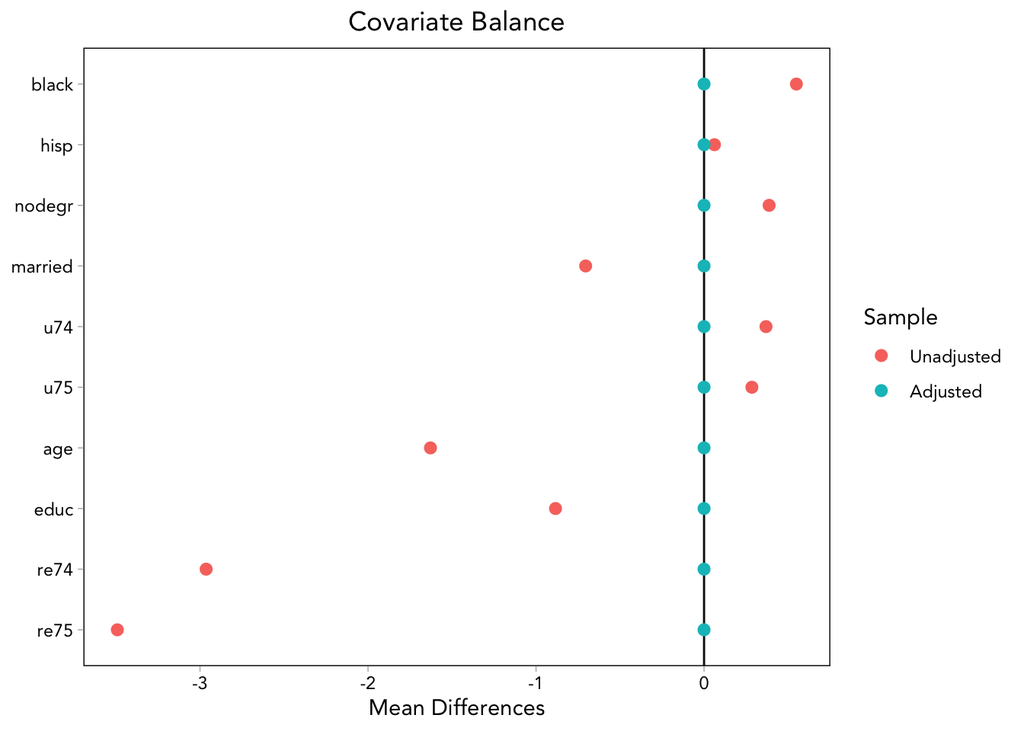

```r
love.plot(ent_weight)
```

```r
lm(re78 ~ treat,
   data = d,
   weights = ent_weight$weights)
```

```
##
## Call:
## lm(formula = re78 ~ treat, data = d, weights = ent_weight$weights)
##
## Coefficients:
## (Intercept)        treat
##      5.4086       0.5677
```

> The balance here looks quite good actually and the ATT is closer to the experimental prediction.
10. Now revisit questions 3 and 5-9. This time, instead of just using simple regressions to estimate the ATT, estimate full outcome regressions using the dataset you “preprocesssed” with matching or weighting. How does this affect the estimates?

```r
form <- f.build("re78", c("treat", "black", "hisp", "nodegr",
                          "married", "u74", "u75", "age", "educ",
                          "re74", "re75"))

m_exact <- lm(form, data = d, weights = ex_m1$weights)
m_psmatch <- lm(form, data = d, weights = ps_rep$weights)
m_pswt <- lm(form, data = d, weights = ps_weight$weights)
m_cbps <- lm(form, data = d, weights = cov_bal_weight$weights)
m_mahal <- lm(form, data = d, weights = mahal_match$weights)
m_ebal <- lm(form, data = d, weights = ent_weight$weights)

library(texreg)
```

```r
texreg::screenreg(
  list(m_exact, m_psmatch, m_pswt, m_cbps, m_mahal, m_ebal),
  custom.model.names = (c("Exact", "PS-M", "PS-W", "CBPS-W", "Mahal-M", "Ent-W")),
  custom.coef.map = list("treat" = "ATT"))
```

```
##
## =====================================================================
##            Exact     PS-M     PS-W        CBPS-W    Mahal-M  Ent-W
## ---------------------------------------------------------------------
## ATT           0.77    -0.02      0.67 **     0.26    -0.39      0.57
##              (0.43)   (0.84)    (0.26)      (0.27)   (0.79)    (0.37)
## ---------------------------------------------------------------------
## R^2           0.63     0.11      0.19        0.16     0.10      0.36
## Adj. R^2      0.63     0.08      0.19        0.16     0.07      0.36
## Num. obs.  2379      389      2510        2510      395      2510
## =====================================================================
## *** p < 0.001; ** p < 0.01; * p < 0.05
```

> This is a bunch of information, but we can see that the Propensity score matching and Mahalanobis models did exceedingly poor as they have such small sample sizes. The Extropy models did pretty good on balance and the ATT is reasonable as is the case for propensity score weighting and exact matching (aside from exact matching’s obvious limitations for covariate complexity).